# Chapter 18: Dynamic Reports with RMarkdown

Christine Limonte

9/1/2020

# 1 Setting Up a Report

RMarkdown is a development framework that can be used to generate documents in different formats - .html files, .pdf files, and slideshows using *ioslides* or *slidy*.

RMarkdown documents are created from a combination of two packages, included in Rstudio:

- **rmarkdown**: processes markdown, generates output
- **knitr**: runs Rcode and produces Markdown-like output

Let’s walk through how to create a **.Rmd** file and its basic structure!

# 2 Integrating Markdown and R Code

Behold - an **R code chunk** below.

```r
#I am a code chunk. I can be created using cmd+alt+i (or in a mac, cmd+opt+i)!
a <- 1+1
a
```

```
## [1] 2
```

```r
a*4
```

```
## [1] 8
```

What if you just want to show the output and hide the code?

```
## [1] "no problem! just specify the additional configuration option at the start of your code chunk! in this case, I used {r, echo=FALSE}"
```

```r
#Can you guess which configuration is being used here?
1+1
```

Code can also be added **inline**. Here I am using this technique to multiply 3 by 2934, which equals 8802.

I can also reference the variable “a” I created earlier. Here I add “a” to 4 = 6.

# 3 Rendering Data and Visualizations in Reports

Now we’ll discuss how to render dynamic, complex output using R Markdown.

## 3.1 Rendering Strings

```
## [1] "You can display a string like this"
```

or have it stored as a variable, then include the variable as an inline expression…

or use the function *cat* with the configuration *results = ‘asis’!*

## 3.2 Rendering Markdown Lists

Markdown lists can be created in code chunks, then displayed inline.

```r
#Method 1:making a list variable
ex_list <- "
- Lions
- Tigers
- Bears"

#Method 2:making a vector of animals then using code to make this a bulleted list

animals <- c("Lions", "Tigers","Bears")
test_list <- paste("-", animals, collapse = "\n")
```

Voila, our list using **Method 1**:

- Lions
- Tigers
- Bears

And **Method 2**:

- Lions
- Tigers
- Bears

*Note: if you forget to include the “r” in you inline code, your result will look like this: `ex_list`*

## 3.3 Rendering Tables

Let’s make a pretty table. Here is a raw “table-type” output from R using a dataset that came with Rstudio, ‘mtcars’.

```r
head(mtcars)
```

```
##                    mpg cyl disp  hp drat    wt  qsec vs am gear carb
## Mazda RX4         21.0   6  160 110 3.90 2.620 16.46  0  1    4    4
## Mazda RX4 Wag     21.0   6  160 110 3.90 2.875 17.02  0  1    4    4
## Datsun 710        22.8   4  108  93 3.85 2.320 18.61  1  1    4    1
## Hornet 4 Drive    21.4   6  258 110 3.08 3.215 19.44  1  0    3    1
## Hornet Sportabout 18.7   8  360 175 3.15 3.440 17.02  0  0    3    2
## Valiant           18.1   6  225 105 2.76 3.460 20.22  1  0    3    1
```

Now look how much better it looks when I use the *knitr* function *kable( )!*

```r
kable(head(mtcars))
```

|  | mpg | cyl | disp | hp | drat | wt | qsec | vs | am | gear | carb |
| --- | --- | --- | --- | --- | --- | --- | --- | --- | --- | --- | --- |
| Mazda RX4 | 21.0 | 6 | 160 | 110 | 3.90 | 2.620 | 16.46 | 0 | 1 | 4 | 4 |
| Mazda RX4 Wag | 21.0 | 6 | 160 | 110 | 3.90 | 2.875 | 17.02 | 0 | 1 | 4 | 4 |
| Datsun 710 | 22.8 | 4 | 108 | 93 | 3.85 | 2.320 | 18.61 | 1 | 1 | 4 | 1 |
| Hornet 4 Drive | 21.4 | 6 | 258 | 110 | 3.08 | 3.215 | 19.44 | 1 | 0 | 3 | 1 |
| Hornet Sportabout | 18.7 | 8 | 360 | 175 | 3.15 | 3.440 | 17.02 | 0 | 0 | 3 | 2 |
| Valiant | 18.1 | 6 | 225 | 105 | 2.76 | 3.460 | 20.22 | 1 | 0 | 3 | 1 |

## 3.4 Rendering Plots

Pretty straightforward - insert code, and off you go!

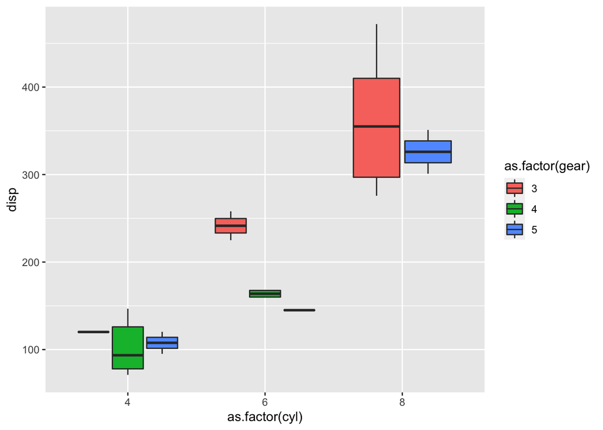

```r
ggplot(data = mtcars)+
  geom_boxplot(aes(x=as.factor(cyl), y=disp, fill=as.factor(gear)))
```

# 4 Sharing Reports as Websites

You can save your report as a **.html** file and upload this onto Github. Github can **host** webpages on a publicly accessible web server.

Behold -

https://climonte.github.io/hello-world/

# 5 R Markdown in Action: Reporting on Life Expectancy

```r
life_exp <- read.csv("~/Desktop/life_exp.csv")

# Which country had the longest life expectancy in 2015?
longest_le <- life_exp %>%
  filter(X2015 == max(X2015, na.rm = T)) %>%
  select(Country.Name, X2015) %>%
  mutate(expectancy = round(X2015, 1)) # rename and format column
longest_le
```

```
##           Country.Name    X2015 expectancy
## 1 Hong Kong SAR, China 84.27805       84.3
```

```r
# Which country had the shortest life expectancy in 2015?
shortest_le <- life_exp %>%
  filter(X2015 == min(X2015, na.rm = T)) %>%
  select(Country.Name, X2015) %>%
  mutate(expectancy = round(X2015, 1)) # rename and format column
shortest_le
```

```
##               Country.Name    X2015 expectancy
## 1 Central African Republic 51.37785       51.4
```

```r
# Calculate range in life expectancies
le_difference <- longest_le$expectancy - shortest_le$expectancy
le_difference
```

```
## [1] 32.9
```

```r
# What are the 10 countries that experienced the greatest gain in life expectancy?
top_10_gain <- life_exp %>%
  mutate(gain = X2015 - X1960) %>%
  top_n(10, wt = gain) %>% # a handy dplyr function!
  arrange(-gain) %>%
  mutate(gain_formatted = paste(format(round(gain, 1), nsmall = 1), "years")) %>%
  select(Country.Name, gain_formatted)

# Join this data frame to a shapefile that describes how to draw each country
# The `rworldmap` package provides a helpful function for doing this
mapped_data <- joinCountryData2Map(
  life_exp,
  joinCode = "ISO3",
  nameJoinColumn = "Country.Code",
  mapResolution = "high"
)
```

```
## 214 codes from your data successfully matched countries in the map
## 50 codes from your data failed to match with a country code in the map
## 39 codes from the map weren't represented in your data
```

**Data Summary**

The data reveals the country with the longest life expectancy was Hong Kong SAR, China with a life expectancy of 84.3.

```r
kable(top_10_gain, col.names = c("Country", "Change in Life Expectancy"))
```

| Country | Change in Life Expectancy |
| --- | --- |
| Maldives | 39.8 years |
| Bhutan | 35.3 years |
| Timor-Leste | 34.8 years |
| Nepal | 34.7 years |
| Oman | 34.5 years |
| Tunisia | 33.5 years |
| China | 32.3 years |
| Afghanistan | 31.0 years |
| Iran, Islamic Rep. | 30.8 years |
| Yemen, Rep. | 30.4 years |

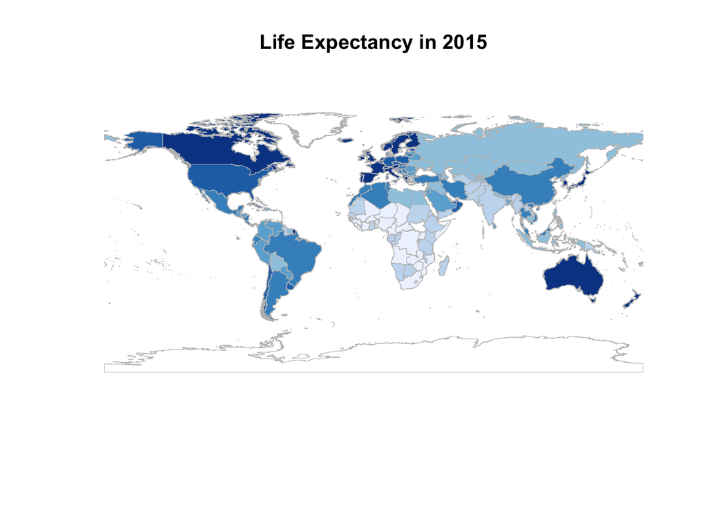

```r
mapCountryData(
  mapped_data,
  mapTitle = "Life Expectancy in 2015",
  nameColumnToPlot = "X2015",
  addLegend = F,
  colourPalette =brewer.pal(7,"Blues")
)
```